# Multivariate Regression Analysis: 10/2024

Ryan Taylor

10/3/2024

# Overview

This document records the methods and results of a multivariate regression analysis on the Volumetric Craniosynostosis data.

## Updates

- Age is correlated with head volume, but not with volume differences.
- Our understanding of the preprocessing involved with the volume differences is mostly correct, but not exactly.
  - I don’t think any of the papers we’ve been sent describe the 12 regions.
- Residuals are highly correlated with original volume differences, but do not look like they are correlated with any of the other variables we have in our data.

## Still to do

- Conduct F tests on predictors
- Write summary of predictors and covariances

# Questions for the team

## Internal

- Why are errors so strongly correlated with the original data?
  - Is there a way to reflect some kind of non-linear relationship?
- Would it make any sense to use percent difference from the normative reference head volume to control for any metrics associated with the normal head volume?
  - We would need each patient’s normative head region volumes

## Collaborators

- How is each region’s volume difference calculated?
- How is age incorporated into the personalized normative reference head volume? The paper potentially suggests it is incorporated as a quadratic term?
  - Why was PCA used to calculate normative reference head volume? Are these based on / do they line up with anatomical regions?
  - When in the process are volumes projected? Are they converted back to volumes in order to calculate the volume differences?

# Load and clean data

First we load the data for the analysis. All of the data is stored in the “Volumetric Results-8-6-2024” Excel file.

We create a clean column indicating the category of suture that we will use in our categorical predictor variable. If a patient has both left coronal and right coronal sutures, we classify them as “Bicoronal.” If they have another combination of multiple sutures, we classify them as “multiple,” and eventually exclude them. If they have no sutures, we classify them as “No suture.” Otherwise, we classify them based on the single suture they have.

```r
here::i_am("analysis/2024.09.27 Meeting Doc.Rmd")

# File saved in "data" folder one level above repo
cranio_raw <- read_xlsx(here::here("../data/VolumetricResults-8-6-2024.xlsx"))

cranio <- cranio_raw %>% clean_names()

sut <- cranio %>% select(matches("fused")) %>%
  mutate(i = 1:n()) %>%
  pivot_longer(cols = -i) %>%
  mutate(suture = if_else(value == 1, name, NA_character_)) %>%
  group_by(i) %>%
  summarize(sutures = paste(na.omit(suture), collapse = "/")) %>%
  ungroup() %>%
  arrange(i)

cranio %<>%
  bind_cols(sut %>% select(sutures)) %>%
  mutate(num_sutures = rowSums(select(., matches("fused"))),
         suture_type = case_when(num_sutures = 2 &
                                   left_coronal_fused == 1 &
                                   right_coronal_fused == 1 ~ "bicoronal",
                                 num_sutures > 1 ~ "multiple",
                                 num_sutures == 0 ~ "no_suture",
                                 T ~ sutures)) %>%
  mutate(suture_type = str_remove_all(suture_type, "_fused"))
```

# Summaries for data cleaning

Our data’s observations are at the image level. Our first task is to summarize the frequency of one individual patient having multiple pictures. We use the “UID” column to identify individual patients.

```r
# Summarize counts
cran_summ <- cranio %>%
  summarize(rows = n(),
            pics = n_distinct(image_identifier),
            patients = n_distinct(uid))

kable(cran_summ, caption = "All pictures and patients")
```

All pictures and patients

| rows | pics | patients |
| --- | --- | --- |
| 2626 | 2626 | 2464 |

```r
# Multiple pictures
multi_pic <- cranio %>%
  arrange(uid, age_at_image_days) %>%
  group_by(uid, suture_type) %>%
  mutate(days_diff = age_at_image_days - lag(age_at_image_days, 1)) %>%
  summarize(pics = n(),
            avg_day_diff = mean(days_diff, na.rm = T)) %>%
  ungroup() %>%
  group_by(pics, suture_type) %>%
  summarize(patients = n_distinct(uid),
            avg_days_between = weighted.mean(avg_day_diff, pics)) %>%
  ungroup() %>%
  arrange(desc(pics))

kable(multi_pic, caption = "Repeat Visits")
```

Repeat Visits

| pics | suture_type | patients | avg_days_between |
| --- | --- | --- | --- |
| 5 | sagittal | 1 | 59.00000 |
| 4 | bicoronal | 1 | 309.66667 |
| 4 | right_coronal | 1 | 47.33333 |
| 4 | sagittal | 2 | 270.33333 |
| 3 | bicoronal | 1 | 105.00000 |
| 3 | left_lambdoid | 1 | 35.00000 |
| 3 | metopic | 9 | 98.22222 |
| 3 | multiple | 1 | 77.00000 |
| 3 | right_coronal | 2 | 47.25000 |
| 3 | right_lambdoid | 2 | 81.50000 |
| 3 | sagittal | 9 | 62.38889 |
| 2 | bicoronal | 5 | 704.00000 |
| 2 | left_coronal | 1 | 86.00000 |
| 2 | left_lambdoid | 2 | 52.50000 |
| 2 | metopic | 19 | 222.47368 |
| 2 | multiple | 5 | 58.20000 |
| 2 | right_coronal | 5 | 85.20000 |
| 2 | sagittal | 59 | 64.33898 |
| 1 | bicoronal | 76 |  |
| 1 | left_coronal | 35 |  |
| 1 | left_lambdoid | 3 |  |
| 1 | metopic | 90 |  |
| 1 | multiple | 22 |  |
| 1 | no_suture | 1718 |  |
| 1 | right_coronal | 45 |  |
| 1 | right_lambdoid | 1 |  |
| 1 | sagittal | 348 |  |

Next, we summarize the frequency of different suture types in the data. We also summarize the specific types of multiple sutures, and investigate whether there are any patients whose diagnosis changes over time.

```r
# Suture types
sut_type <- cranio %>%
  group_by(suture_type) %>%
  summarize(pics = n(),
            patients = n_distinct(uid)) %>%
  ungroup() %>%
  arrange(desc(pics)) %>%
  mutate(pats_included = if_else(suture_type %in% c("multiple", "right_lambdoid", "left_lambdoid"), 0, patients)) %>%
  adorn_totals("row")

kable(sut_type, caption = "Suture Representation")
```

Suture Representation

| suture_type | pics | patients | pats_included |
| --- | --- | --- | --- |
| no_suture | 1718 | 1718 | 1718 |
| sagittal | 506 | 419 | 419 |
| metopic | 155 | 118 | 118 |
| bicoronal | 93 | 83 | 83 |
| right_coronal | 65 | 53 | 53 |
| left_coronal | 37 | 36 | 36 |
| multiple | 35 | 28 | 0 |
| left_lambdoid | 10 | 6 | 0 |
| right_lambdoid | 7 | 3 | 0 |
| Total | 2626 | 2464 | 2427 |

```r
# Multiple sutures

multi_sut <- cranio %>%
  filter(suture_type == "multiple") %>%
  group_by(sutures) %>%
  summarize(pics = n(),
            patients = n_distinct(uid)) %>%
  ungroup() %>%
  arrange(desc(pics))

kable(multi_sut, caption = "Multiple Sutures (Exc.) Bicoronal")
```

Multiple Sutures (Exc.) Bicoronal

| sutures | pics | patients |
| --- | --- | --- |
| metopic_fused/sagittal_fused | 9 | 8 |
| sagittal_fused/left_coronal_fused | 7 | 4 |
| sagittal_fused/left_lambdoid_fused/right_lambdoid_fused | 7 | 5 |
| sagittal_fused/right_coronal_fused | 3 | 2 |
| sagittal_fused/right_lambdoid_fused | 2 | 2 |
| left_coronal_fused/left_lambdoid_fused | 1 | 1 |
| metopic_fused/left_lambdoid_fused/right_lambdoid_fused | 1 | 1 |
| right_coronal_fused/right_lambdoid_fused | 1 | 1 |
| sagittal_fused/left_coronal_fused/left_lambdoid_fused/right_lambdoid_fused | 1 | 1 |
| sagittal_fused/right_coronal_fused/left_lambdoid_fused | 1 | 1 |
| sagittal_fused/right_coronal_fused/left_lambdoid_fused/right_lambdoid_fused | 1 | 1 |
| sagittal_fused/right_coronal_fused/right_lambdoid_fused | 1 | 1 |

```r
# Changes within patient
patient <- cranio %>%
  arrange(uid, age_at_image_days) %>%
  group_by(uid) %>%
  summarize(pics = n(),
            suture_prog = paste(na.omit(unique(suture_type)))) %>%
  ungroup() %>%
  group_by(suture_prog) %>%
  summarize(pics = sum(pics),
            patients = n()) %>%
  ungroup() %>%
  arrange(desc(pics))

kable(patient, caption = "Patient Progressions: No Changes in Diagnosis")
```

Patient Progressions: No Changes in Diagnosis

| suture_prog | pics | patients |
| --- | --- | --- |
| no_suture | 1718 | 1718 |
| sagittal | 506 | 419 |
| metopic | 155 | 118 |
| bicoronal | 93 | 83 |
| right_coronal | 65 | 53 |
| left_coronal | 37 | 36 |
| multiple | 35 | 28 |
| left_lambdoid | 10 | 6 |
| right_lambdoid | 7 | 3 |

# Data cleaning

Based on these summaries, there are some rare categories of data that we should exclude to reduce the variability of the data.

We use one image from each patient, which we choose as the last image taken for each patient. We also exclude multiple sutures and lambdoid sutures.

```r
# Filter to regression subset
cranio_reg <- cranio %>%
  # Exclude rare sutures
  filter(!suture_type %in% c("multiple", "left_lambdoid", "right_lambdoid")) %>%
  # Filter to one picture per patient
  arrange(uid, age_at_image_days) %>%
  group_by(uid) %>%
  slice_tail(n=1) %>%
  ungroup() %>%
  mutate(suture_type = factor(suture_type, levels = sut_type$suture_type))
```

# Data investigation

With this clean data, we perform some summaries to ensure that we understand the preprocessing on the data.

First, we calculate the sum of volume differences for each patient across all 12 regions and compare this to the difference between the head volume and personalized normative reference head volume.

These two metrics are very similar, but not exact, so we might not understand how the 12 regions’ volumes are being calculated exactly, but for now we will proceed with the interpretation that each region’s volume difference is subtracting that region’s volume in the personalized normative reference head from that region’s volume in the individual’s head. Because of this, we will not include head volume in the model.

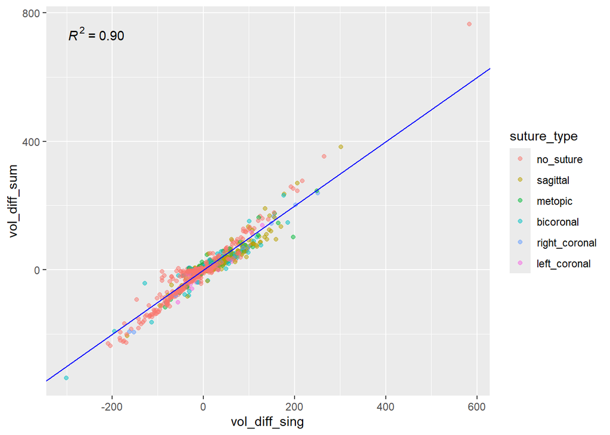

```r
vol_check <- cranio_reg %>%
  mutate(vol_diff_sum = rowSums(select(., matches("region"))),
         vol_diff_sing = head_volume_m_l - personalized_normative_reference_head_volume_m_l)

ggplot(vol_check, aes(x = vol_diff_sing, y = vol_diff_sum)) +
  geom_point(aes(color = suture_type), alpha = 0.5) +
  geom_abline(slope = 1, intercept = 0, color = "blue") +
  stat_poly_eq()
```

# Clean Summary statistics

With the cleaned data, we start with a Table 1 displaying information about the infants in our sample.

```r
demo_table <- table1::table1(~
                               image_type + pt_sex + pt_race + pt_ethnicity +
                               age_at_image_days + head_volume_m_l +
                               personalized_normative_reference_head_volume_m_l | suture_type,
                             data = cranio_reg)

demo_table
```

|  | no_suture (N=1718) | sagittal (N=419) | metopic (N=118) | bicoronal (N=83) | right_coronal (N=53) | left_coronal (N=36) | Overall (N=2427) |
| --- | --- | --- | --- | --- | --- | --- | --- |
| image_type |  |  |  |  |  |  |  |
| CT | 1718 (100%) | 222 (53.0%) | 65 (55.1%) | 77 (92.8%) | 41 (77.4%) | 32 (88.9%) | 2155 (88.8%) |
| 3D photo | 0 (0%) | 197 (47.0%) | 53 (44.9%) | 6 (7.2%) | 12 (22.6%) | 4 (11.1%) | 272 (11.2%) |
| pt_sex |  |  |  |  |  |  |  |
| Female | 783 (45.6%) | 109 (26.0%) | 30 (25.4%) | 43 (51.8%) | 31 (58.5%) | 29 (80.6%) | 1025 (42.2%) |
| Male | 934 (54.4%) | 310 (74.0%) | 88 (74.6%) | 40 (48.2%) | 22 (41.5%) | 7 (19.4%) | 1401 (57.7%) |
| Missing | 1 (0.1%) | 0 (0%) | 0 (0%) | 0 (0%) | 0 (0%) | 0 (0%) | 1 (0.0%) |
| pt_race |  |  |  |  |  |  |  |
| African or African American | 514 (29.9%) | 33 (7.9%) | 4 (3.4%) | 15 (18.1%) | 4 (7.5%) | 9 (25.0%) | 579 (23.9%) |
| American Indian or Alaska Native | 6 (0.3%) | 5 (1.2%) | 0 (0%) | 1 (1.2%) | 1 (1.9%) | 0 (0%) | 13 (0.5%) |
| Asian | 28 (1.6%) | 40 (9.5%) | 16 (13.6%) | 1 (1.2%) | 2 (3.8%) | 1 (2.8%) | 88 (3.6%) |
| Caucasian | 743 (43.2%) | 255 (60.9%) | 75 (63.6%) | 48 (57.8%) | 28 (52.8%) | 19 (52.8%) | 1168 (48.1%) |
| Native Hawaiian or Other Pacific Islander | 3 (0.2%) | 0 (0%) | 0 (0%) | 0 (0%) | 0 (0%) | 0 (0%) | 3 (0.1%) |
| Missing | 424 (24.7%) | 86 (20.5%) | 23 (19.5%) | 18 (21.7%) | 18 (34.0%) | 7 (19.4%) | 576 (23.7%) |
| pt_ethnicity |  |  |  |  |  |  |  |
| Hispanic or Latino | 445 (25.9%) | 97 (23.2%) | 29 (24.6%) | 21 (25.3%) | 13 (24.5%) | 6 (16.7%) | 611 (25.2%) |
| Not Hispanic or Latino | 1029 (59.9%) | 282 (67.3%) | 82 (69.5%) | 57 (68.7%) | 33 (62.3%) | 28 (77.8%) | 1511 (62.3%) |
| Missing | 244 (14.2%) | 40 (9.5%) | 7 (5.9%) | 5 (6.0%) | 7 (13.2%) | 2 (5.6%) | 305 (12.6%) |
| age_at_image_days |  |  |  |  |  |  |  |
| Mean (SD) | 1110 (1090) | 229 (387) | 249 (370) | 609 (856) | 270 (369) | 286 (466) | 868 (1020) |
| Median [Min, Max] | 617 [1.00, 3660] | 124 [0, 3700] | 148 [11.0, 3080] | 193 [1.00, 3600] | 148 [35.0, 2210] | 163 [1.00, 2490] | 379 [0, 3700] |
| head_volume_m_l |  |  |  |  |  |  |  |
| Mean (SD) | 881 (312) | 712 (238) | 723 (257) | 751 (357) | 683 (239) | 644 (204) | 832 (307) |
| Median [Min, Max] | 899 [122, 1860] | 658 [203, 1770] | 667 [272, 1630] | 676 [225, 1520] | 652 [303, 1560] | 626 [336, 1200] | 807 [122, 1860] |
| personalized_normative_reference_head_volume_m_l |  |  |  |  |  |  |  |
| Mean (SD) | 884 (303) | 688 (216) | 702 (230) | 733 (334) | 662 (201) | 630 (186) | 827 (298) |
| Median [Min, Max] | 905 [179, 1660] | 644 [211, 1640] | 662 [278, 1380] | 692 [226, 1510] | 615 [305, 1360] | 624 [350, 1160] | 808 [179, 1660] |

Next, we summarize the dependent variables: volume differences by region.

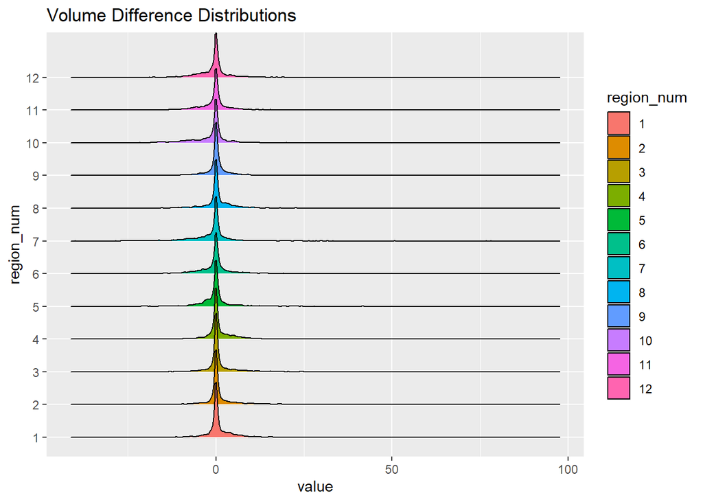

```r
vol_ridge <- cranio_reg %>%
  select(matches("region")) %>%
  pivot_longer(cols = everything()) %>%
  mutate(region_num = str_extract(name, "[0-9]+") %>% as.numeric() %>% as.factor()) %>%
  ggplot(aes(x=value, y=region_num, fill=region_num)) +
  geom_density_ridges() +
  labs(title = "Volume Difference Distributions")

vol_ridge
```

Since a ridge plot reveals long-tailed distributions, we also present jittered points and a boxplot to give a better idea of each region’s frequency of outliers.

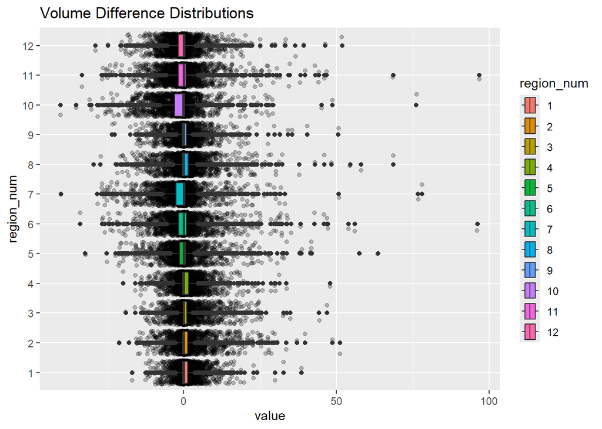

```r
vol_box <- cranio_reg %>%
  select(matches("region")) %>%
  pivot_longer(cols = everything()) %>%
  mutate(region_num = str_extract(name, "[0-9]+") %>% as.numeric() %>% as.factor()) %>%
  ggplot(aes(x=value, y=region_num, fill=region_num)) +
  geom_jitter(width=0.1, alpha = 0.25) +
  geom_boxplot() +
  labs(title = "Volume Difference Distributions")

vol_box
```

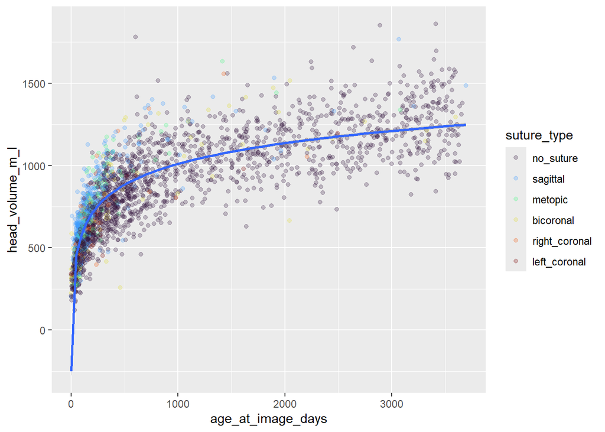

```r
cranio_reg %>%
  filter(age_at_image_days > 0) %>%
  ggplot(aes(x = age_at_image_days, y = head_volume_m_l)) +
  geom_point(aes(color = suture_type), alpha = 0.25) +
  geom_smooth(formula = y ~ log(x)) +
  scale_color_viridis_d(option = "turbo")
```

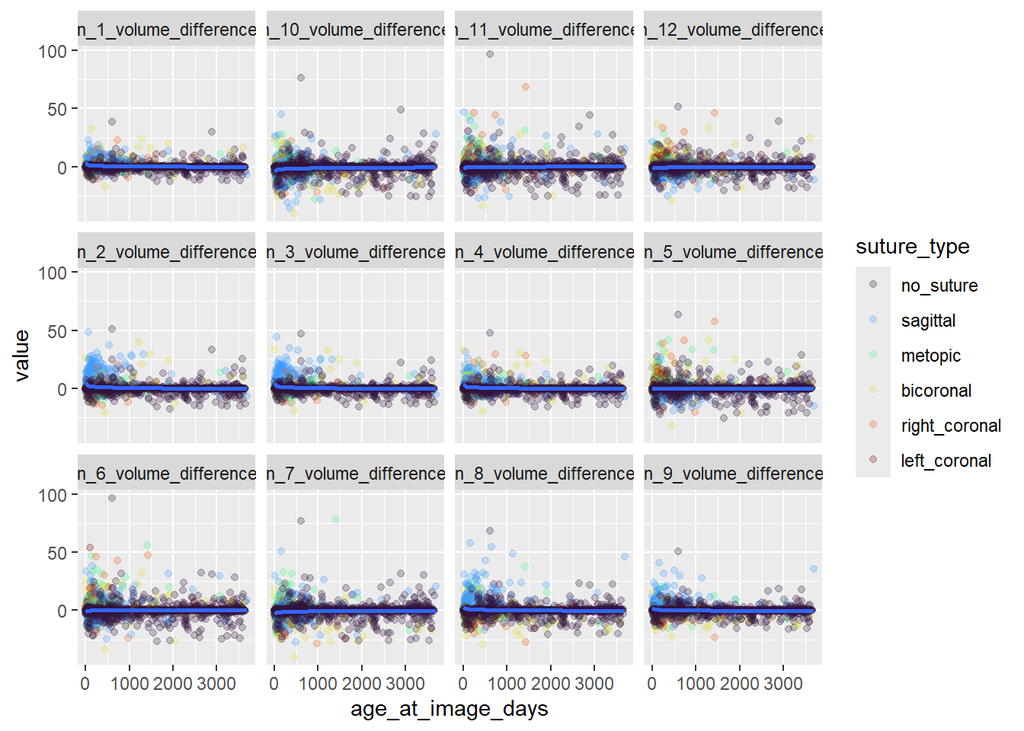

```r
cranio_reg %>%
  pivot_longer(cols = c(matches("region"))) %>%
  filter(age_at_image_days > 0) %>%
  ggplot(aes(x = age_at_image_days, y = value)) +
  geom_point(aes(color = suture_type), alpha = 0.25) +
  geom_smooth(formula = y ~ log(x)) +
  facet_wrap(~name) +
  scale_color_viridis_d(option = "turbo")
```

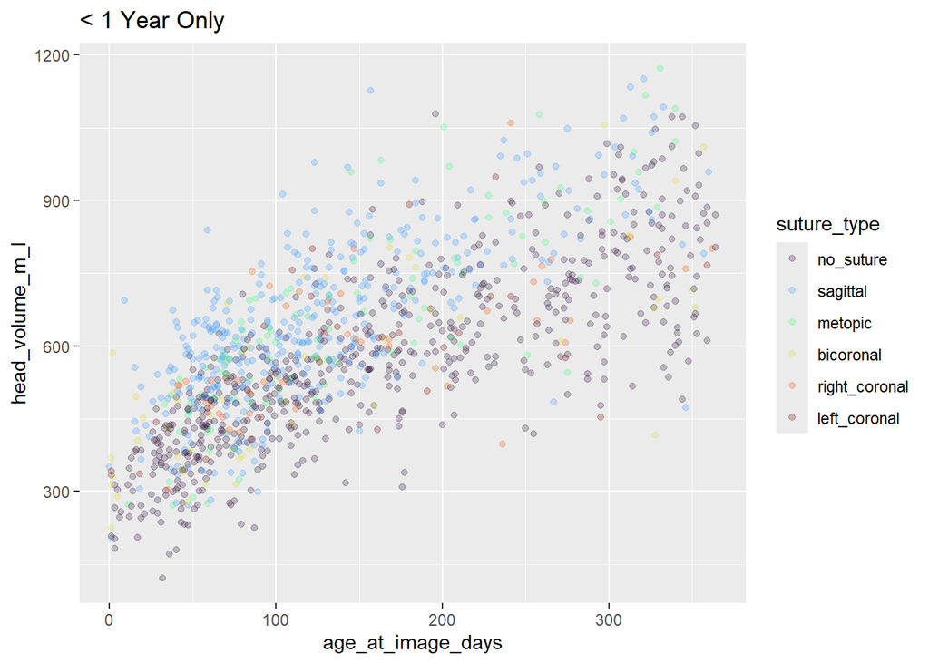

```r
cranio_reg %>%
  filter(age_at_image_days <= 365) %>%
  ggplot(aes(x = age_at_image_days, y = head_volume_m_l)) +
  geom_point(aes(color = suture_type), alpha = 0.25) +
  scale_color_viridis_d(option = "turbo") +
  labs(title = "< 1 Year Only")
```

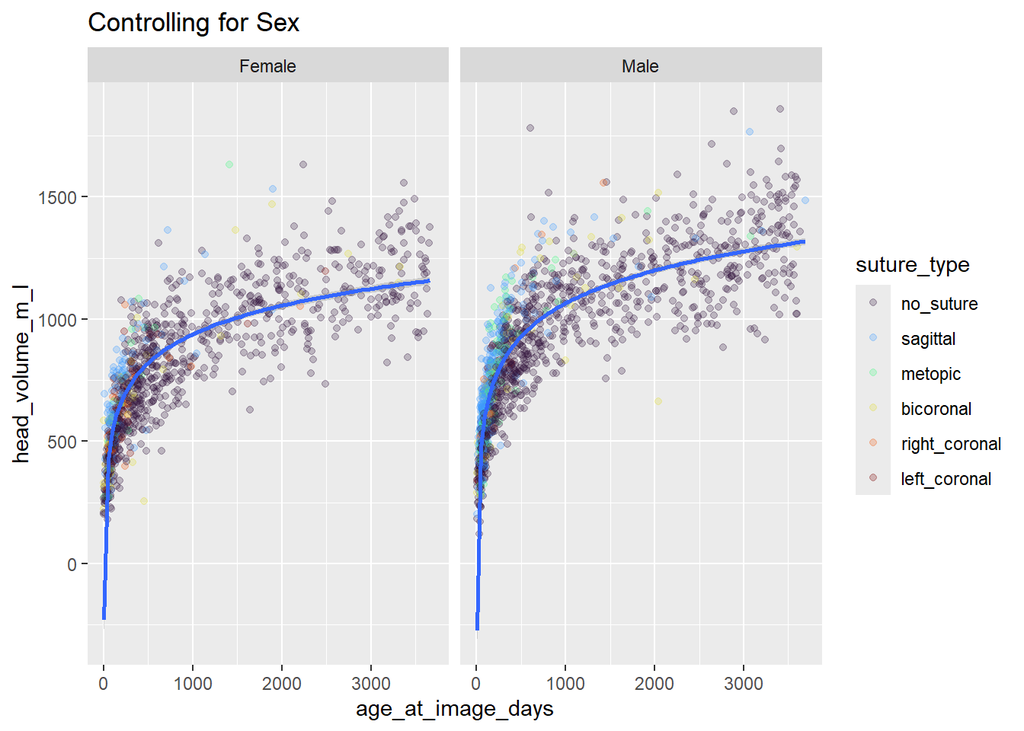

```r
cranio_reg %>%
  filter(age_at_image_days > 0 & !is.na(pt_sex)) %>%
  ggplot(aes(x = age_at_image_days, y = head_volume_m_l)) +
  geom_point(aes(color = suture_type), alpha = 0.25) +
  geom_smooth(formula = y ~ log(x)) +
  facet_wrap(~pt_sex, nrow = 1) +
  scale_color_viridis_d(option = "turbo") +
  labs(title = "Controlling for Sex")
```

## Multivariate Regression

Next, we run a multivariate regression to find the association between the 12 regions’ volume differences in a given patient with that patient’s suture type.

```r
vol_reg <- lm(
  formula(paste("cbind(",
                paste(
                  paste0("region_", 1:12, "_volume_difference_m_l"),
                  collapse = ", "),
                ") ~ ", "suture_type")),
          data = cranio_reg
)
```

The results from this model are presented in the table below.

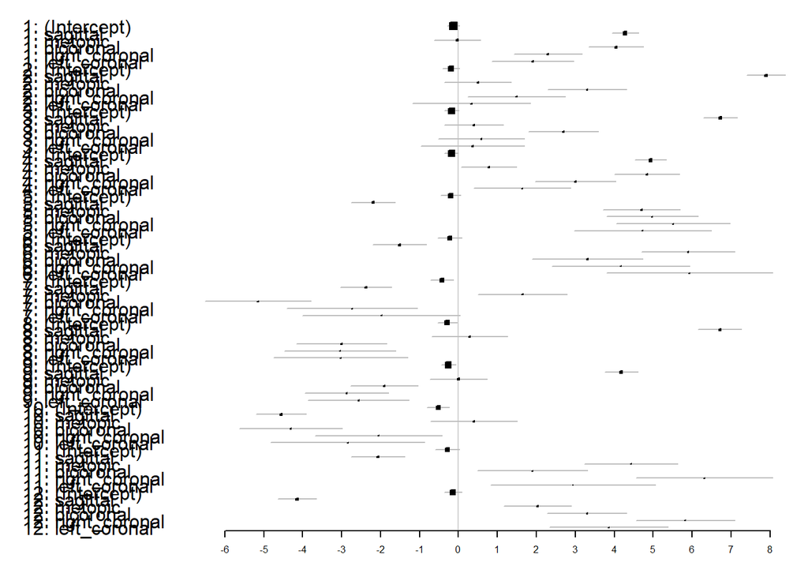

```r
beta_tbl <- broom::tidy(vol_reg)

lm_stats <- distinct(beta_tbl, response) %>%
  mutate(rse = purrr::map_dbl(1:length(summary(vol_reg)),
                                ~summary(vol_reg)[.][[1]]$sigma),
         r_2 = purrr::map_dbl(1:length(summary(vol_reg)),
                                ~summary(vol_reg)[.][[1]]$r.squared),
         adj_r_2 = purrr::map_dbl(1:length(summary(vol_reg)),
                                ~summary(vol_reg)[.][[1]]$adj.r.squared))

beta_tbl %<>% left_join(lm_stats) %>%
  select(response, rse, r_2, adj_r_2, everything()) %>%
  mutate(low_95 = estimate - 1.96*std.error,
         high_95 = estimate + 1.96*std.error,
         region_num = str_extract(response, "[0-9]+") %>% as.numeric(),
         clean_var = str_remove_all(term, "suture_type"),
         term_name = paste0(region_num, ": ", clean_var))

forestplot(beta_tbl, mean = estimate, lower = low_95, upper = high_95, labeltext = term_name)
```

```r
kable(lm_stats, caption = "Model Performance Statistics")
```

Model Performance Statistics

| response | rse | r_2 | adj_r_2 |
| --- | --- | --- | --- |
| region_1_volume_difference_m_l | 3.179254 | 0.2282652 | 0.2266714 |
| region_2_volume_difference_m_l | 4.589231 | 0.2960439 | 0.2945900 |
| region_3_volume_difference_m_l | 4.042270 | 0.2823702 | 0.2808881 |
| region_4_volume_difference_m_l | 3.775664 | 0.2178608 | 0.2162455 |
| region_5_volume_difference_m_l | 5.328120 | 0.1156611 | 0.1138347 |
| region_6_volume_difference_m_l | 6.449086 | 0.0728755 | 0.0709607 |
| region_7_volume_difference_m_l | 6.134527 | 0.0477256 | 0.0457589 |
| region_8_volume_difference_m_l | 5.225187 | 0.2160496 | 0.2144306 |
| region_9_volume_difference_m_l | 3.929689 | 0.1680095 | 0.1662912 |
| region_10_volume_difference_m_l | 5.980315 | 0.0876957 | 0.0858116 |
| region_11_volume_difference_m_l | 6.406212 | 0.0640763 | 0.0621434 |
| region_12_volume_difference_m_l | 4.622508 | 0.1710714 | 0.1693595 |

We create a brain shape to plot the results on top of the region map:

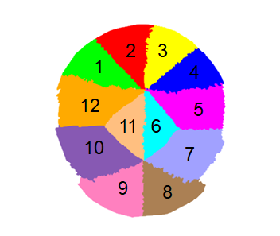

```r
knitr::include_graphics(here::here("../Literature/Region_Diagram.png"))
```

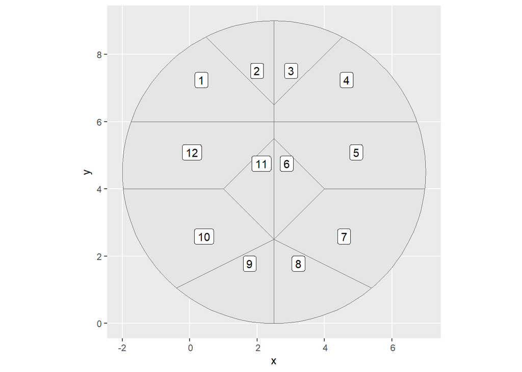

```r
# Manually define center points of regions
brain_points <- tribble(
  ~region, ~x, ~y,
  1, 1, 7,
  2, 2, 8,
  3, 3, 8,
  4, 4, 7,
  5, 4, 5,
  6, 3, 4,
  7, 4, 3,
  8, 3, 1,
  9, 2, 1,
  10, 1, 3,
  11, 2, 4,
  12, 1, 5
) %>%
  st_as_sf(coords = c("x", "y"), remove = F)

# Create shapes around these points
g = st_combine(st_geometry(brain_points)) # make multipoint
v = st_voronoi(g)
v = st_collection_extract(v)

# Add region numbers
brain_shapes <- v[unlist(st_intersects(brain_points, v))] %>%
  st_as_sf() %>%
  mutate(region_num = 1:n())

# Create circle
brain_circle <- tibble(x = 2.5, y = 4.5) %>%
  st_as_sf(coords = c("x", "y")) %>%
  st_buffer(4.5)

brain_shapes <- st_intersection(brain_shapes, brain_circle)

ggplot() +
  geom_sf(data = brain_shapes) +
  geom_sf_label(data = brain_shapes, aes(label = region_num))
```

Next, we plot the coefficients on the map of the brain regions.

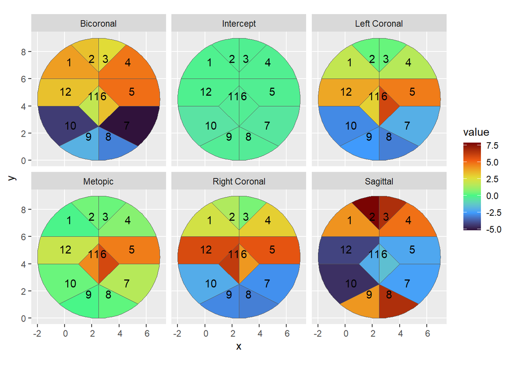

```r
# Extract and clean coefficients
reg_coeffs <- coefficients(vol_reg) %>%
  as.data.frame() %>%
  rownames_to_column() %>%
  pivot_longer(-rowname) %>%
  mutate(region_num = str_extract(name, "[0-9]+") %>% as.numeric(),
         suture_clean = str_remove_all(rowname, "suture_type") %>%
           str_replace_all("_", " ") %>%
           str_remove_all("\\(|\\)") %>%
           str_to_title()) %>%
  left_join(brain_shapes) %>%
  st_as_sf()

# Plot coefficients
coeff_plot <- ggplot() +
  geom_sf(data = reg_coeffs, aes(fill = value)) +
  geom_sf_text(data = reg_coeffs, aes(label = region_num)) +
  facet_wrap(~suture_clean) +
  scale_fill_viridis_c(option = "turbo")

coeff_plot
```

## Model Diagnostics

Next, we check the shape of the residuals.

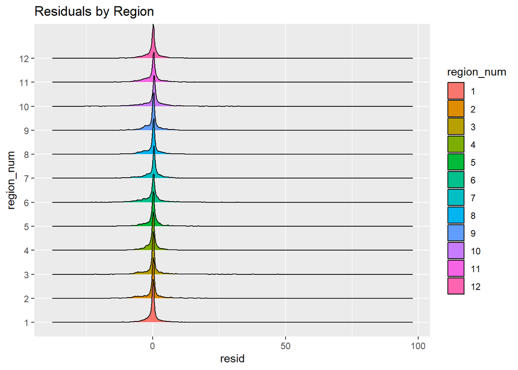

```r
# Plot residual distributions
resid_df <- vol_reg$residuals %>%
  as.data.frame() %>%
  rownames_to_column() %>%
  pivot_longer(-rowname, values_to = "resid")

vols_df <- cranio_reg %>%
  select(c(matches("region"), pt_sex, age_at_image_days, suture_type, pt_race, pt_ethnicity)) %>%
  mutate(rowname = as.character(1:n())) %>%
  pivot_longer(cols = matches("region"), values_to = "vol_diff")

resid_df %<>%
  full_join(vols_df) %>%
  mutate(region_num = str_extract(name, "[0-9]+") %>%
           as.numeric() %>% as.factor())

resid_ridge <- ggplot(resid_df,
                     aes(x = resid, y = region_num, fill = region_num)) +
  geom_density_ridges() +
  labs(title = "Residuals by Region")

resid_box <- ggplot(resid_df,
                     aes(x = resid, y = region_num, fill = region_num)) +
  geom_jitter(width=0.1, alpha = 0.25) +
  geom_boxplot() +
  labs(title = "Residuals by Region")

resid_ridge
```

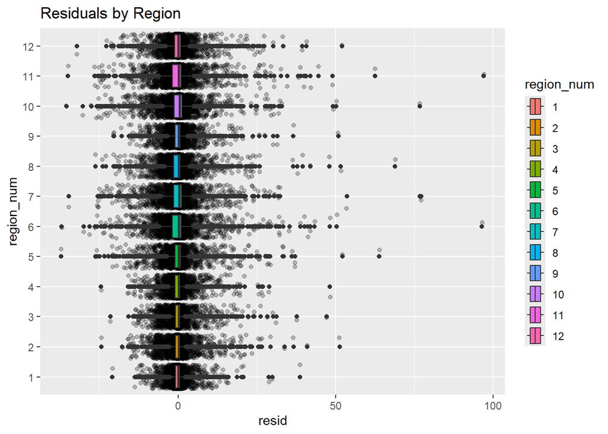

```r
resid_box
```

We then plot the residuals against their corresponding original volume differences. This shows that we are not picking up a substantial amount of variance.

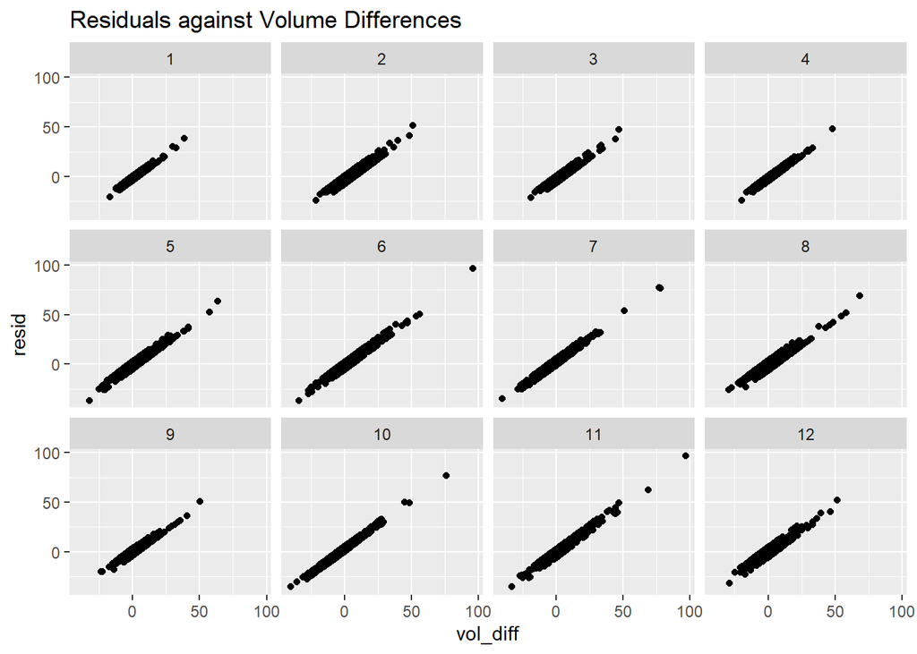

```r
resid_df %>%
  ggplot(aes(x = vol_diff, y = resid)) +
  geom_point() +
  facet_wrap(~region_num) +
  labs(title = "Residuals against Volume Differences")
```

We also plot the residuals against variables in the model and other demographic variables. However, none of these variables appear to be correlated with the residuals.

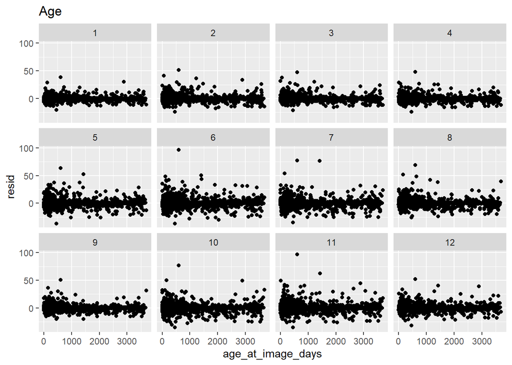

```r
resid_df %>%
  ggplot(aes(x = age_at_image_days, y = resid)) +
  geom_point() +
  facet_wrap(~region_num) +
  labs(title = "Age")
```

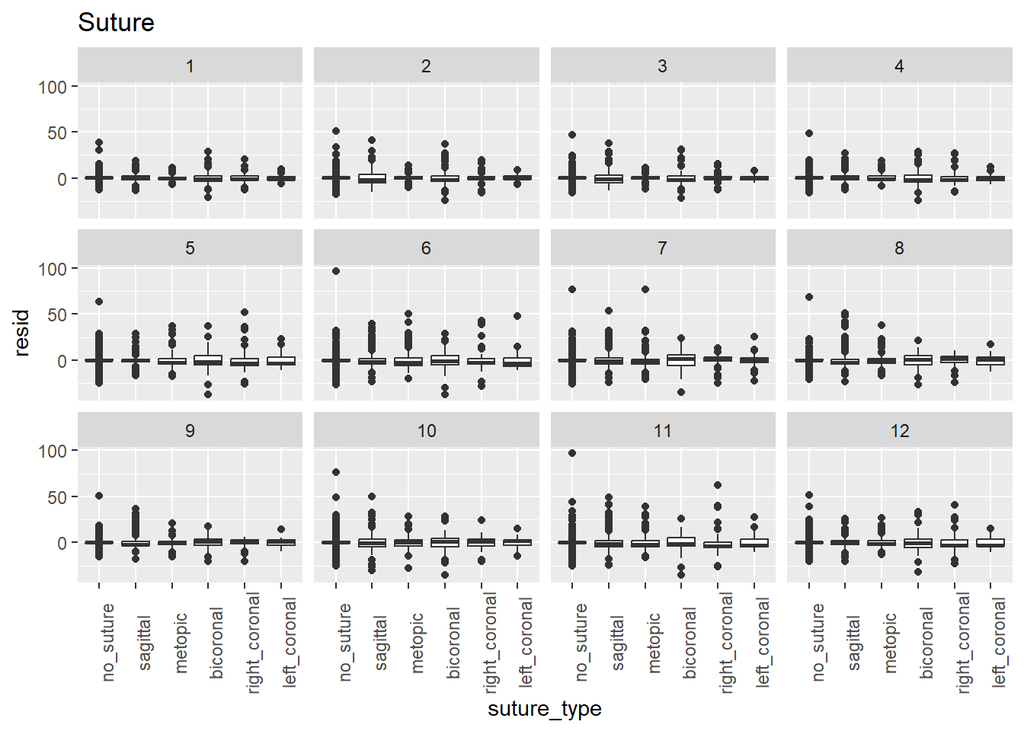

```r
resid_df %>%
  ggplot(aes(x = suture_type, y = resid)) +
  geom_boxplot() +
  facet_wrap(~region_num) +
  labs(title = "Suture") +
  theme(axis.text.x = element_text(angle = 90))
```

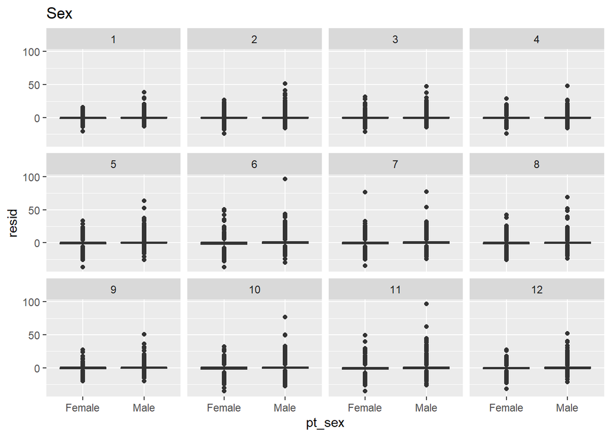

```r
resid_df %>%
  filter(!is.na(pt_sex)) %>%
  ggplot(aes(x = pt_sex, y = resid)) +
  geom_boxplot() +
  facet_wrap(~region_num) +
  labs(title = "Sex")
```

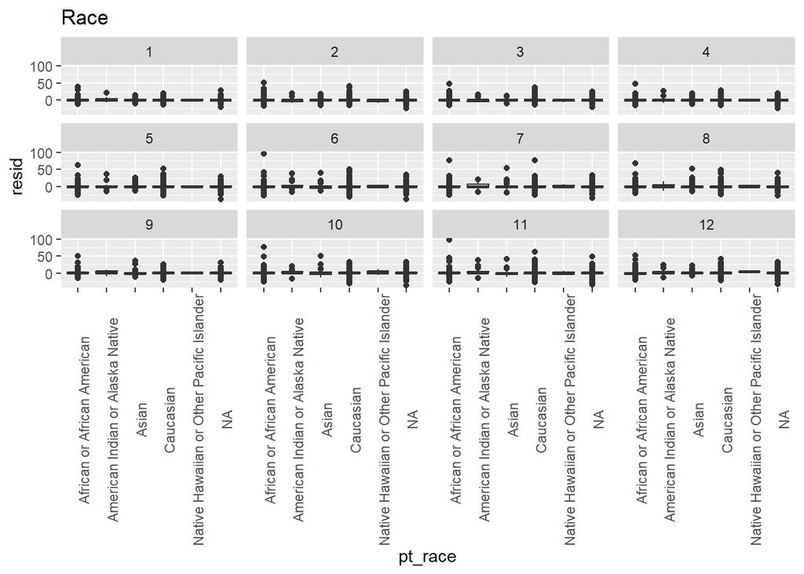

```r
resid_df %>%
  ggplot(aes(x = pt_race, y = resid)) +
  geom_boxplot() +
  facet_wrap(~region_num) +
  labs(title = "Race") +
  theme(axis.text.x = element_text(angle = 90))
```

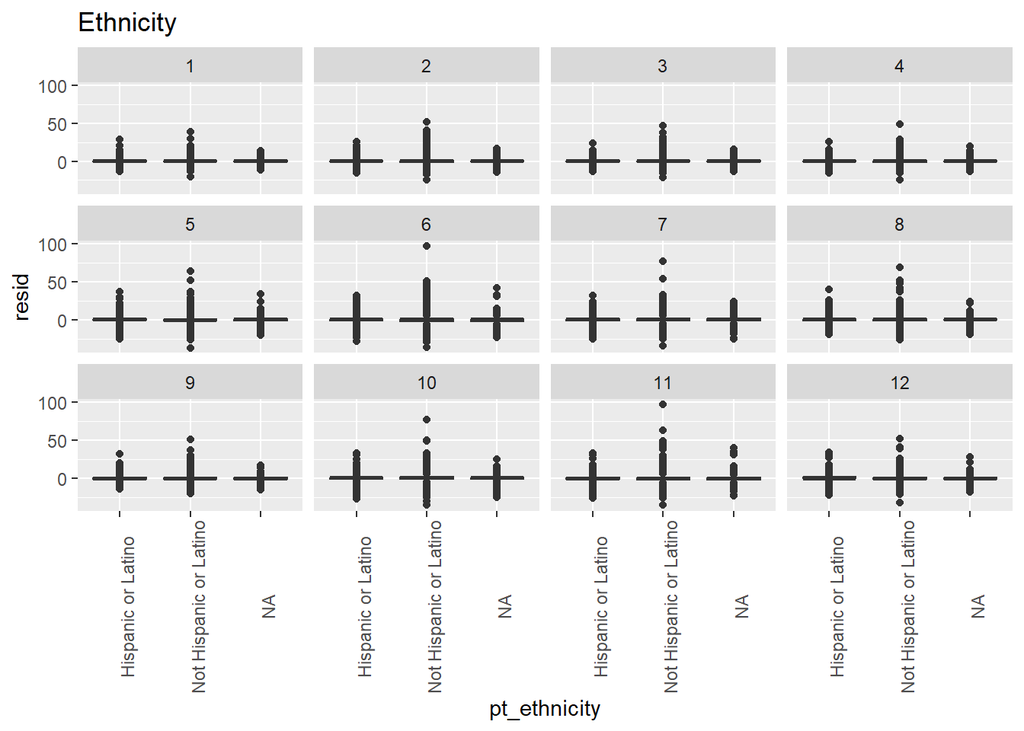

```r
resid_df %>%
  ggplot(aes(x = pt_ethnicity, y = resid)) +
  geom_boxplot() +
  facet_wrap(~region_num) +
  labs(title = "Ethnicity") +
  theme(axis.text.x = element_text(angle = 90))
```

We also plot the covariance matrices of the volume differences and the residuals.

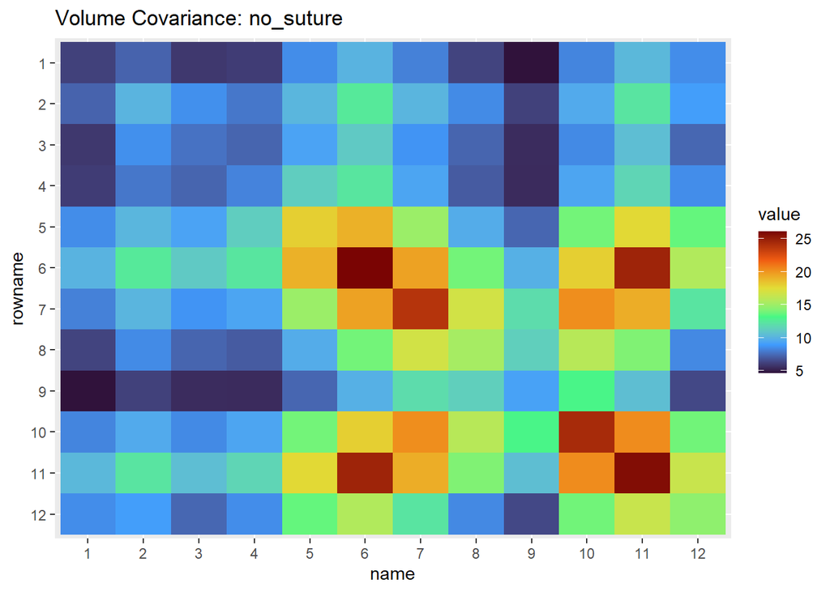

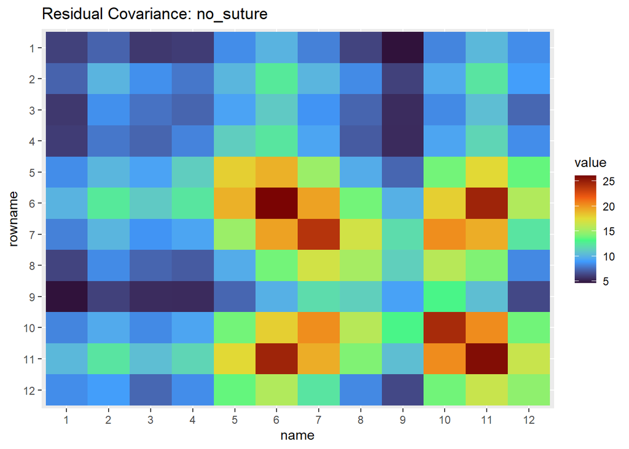

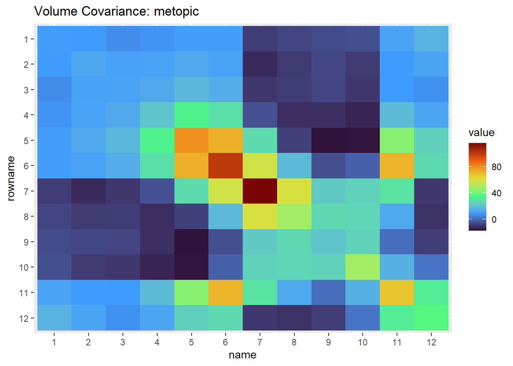

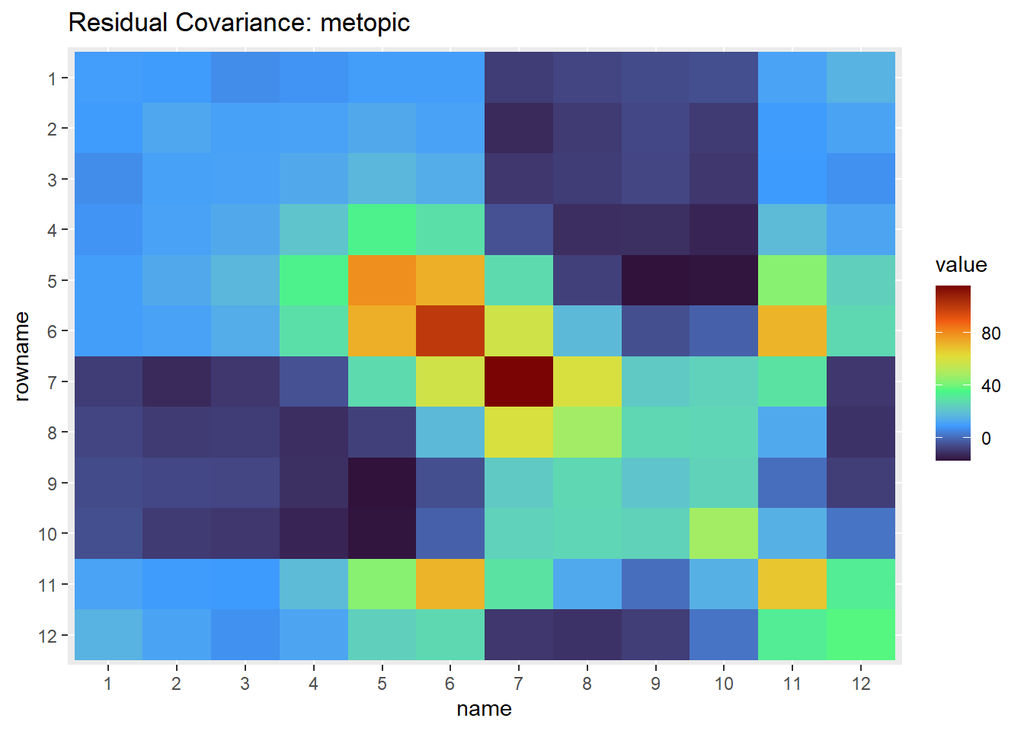

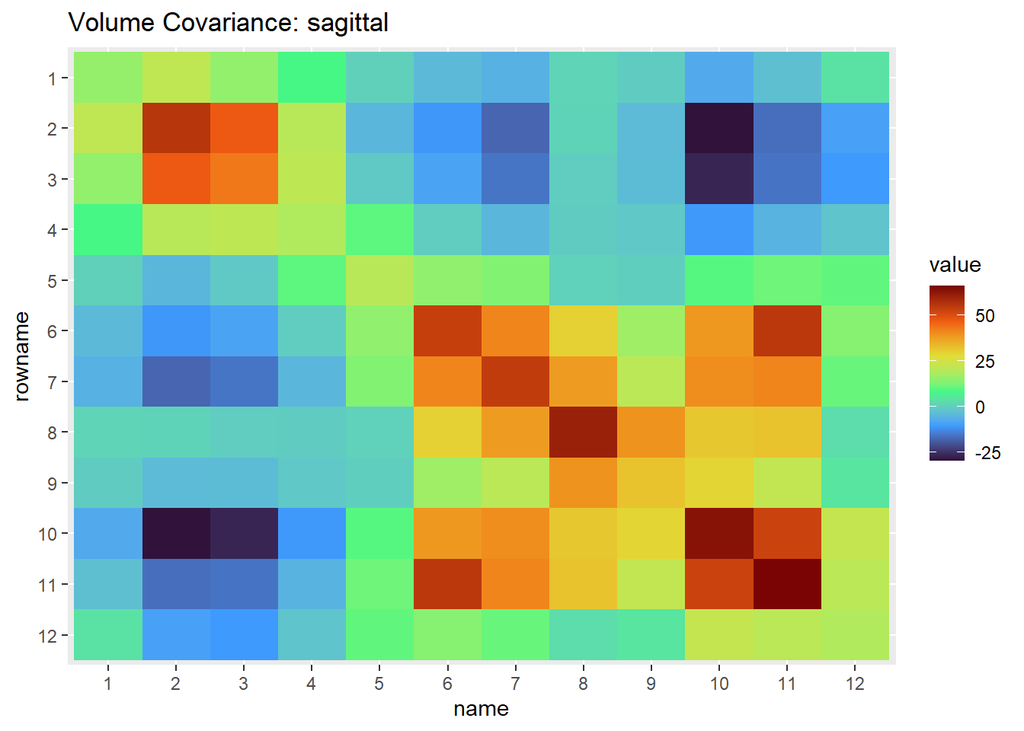

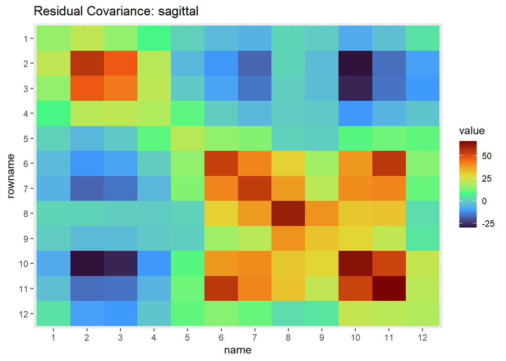

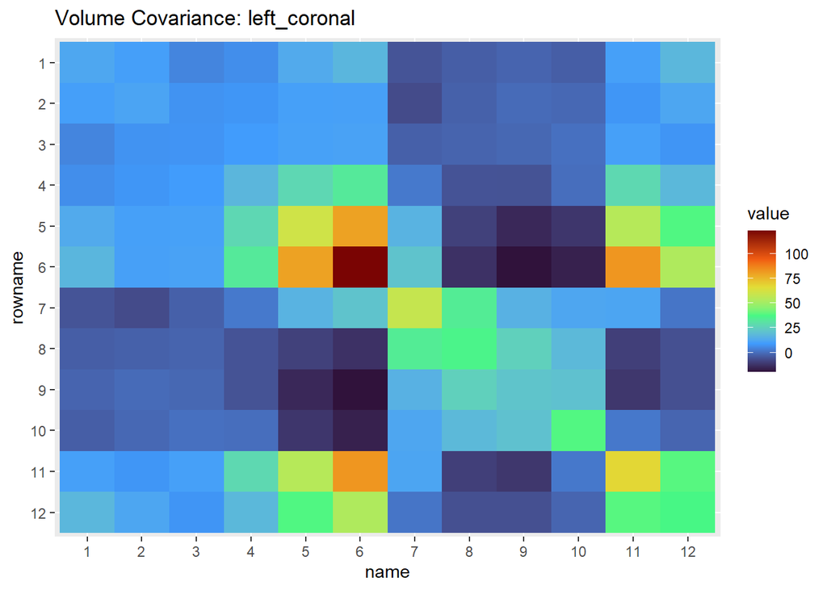

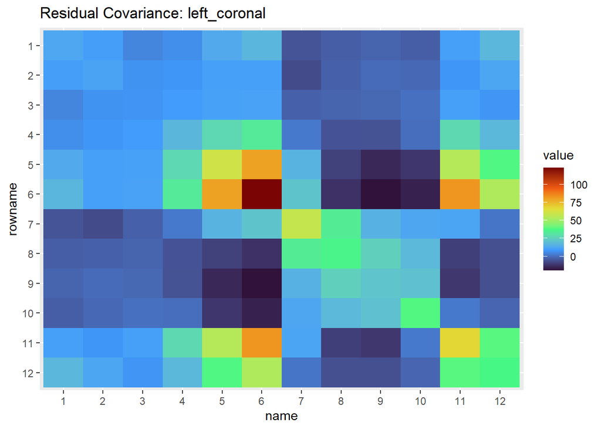

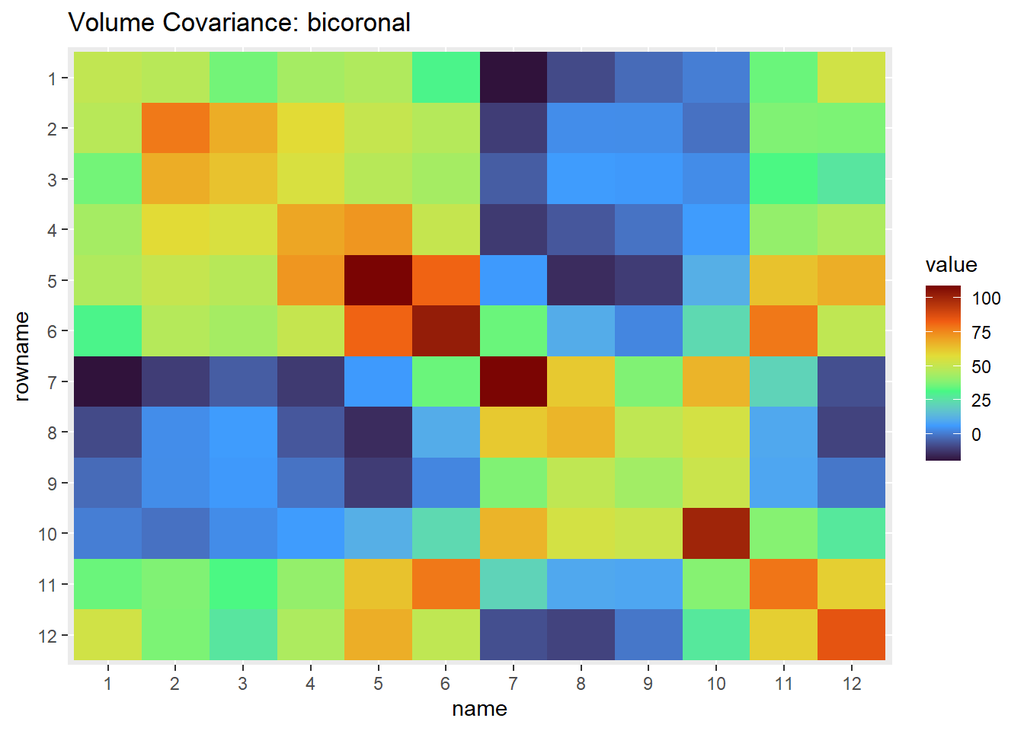

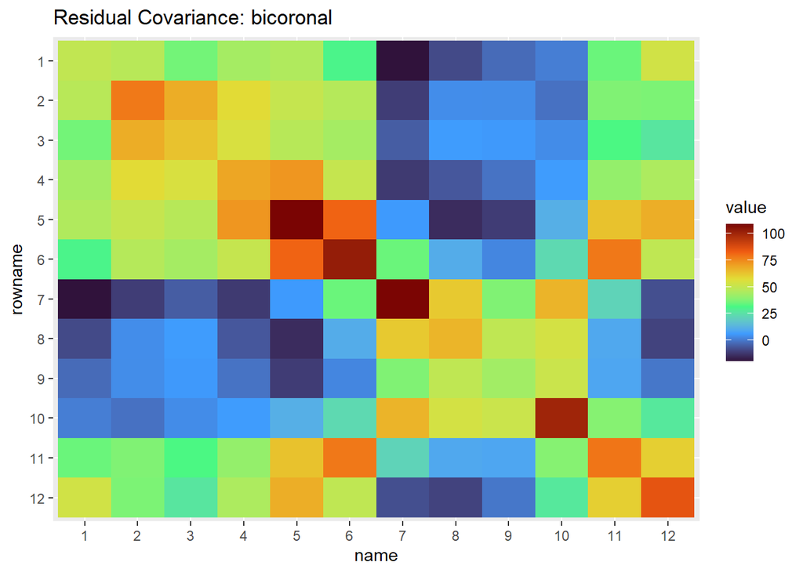

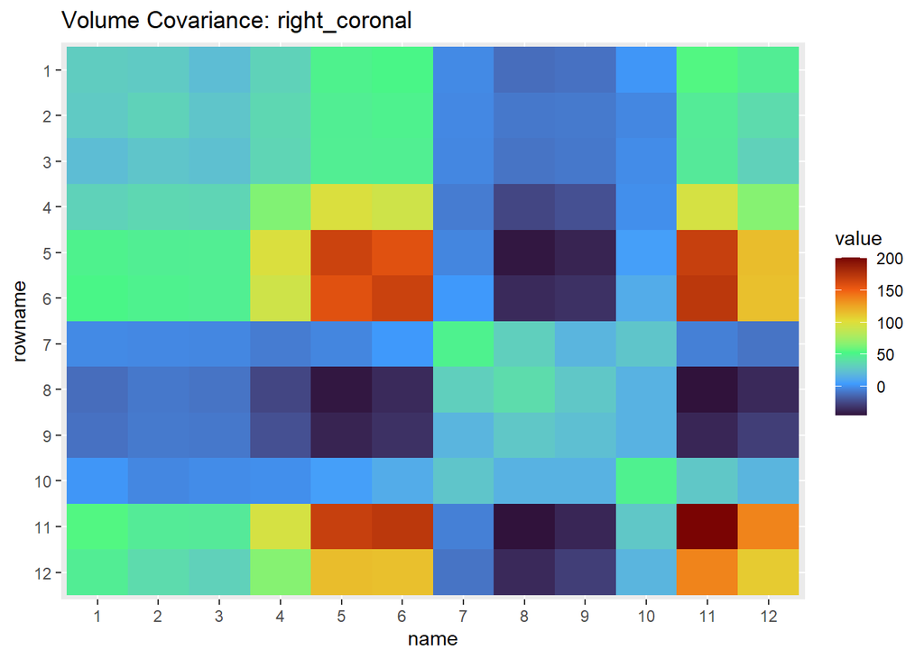

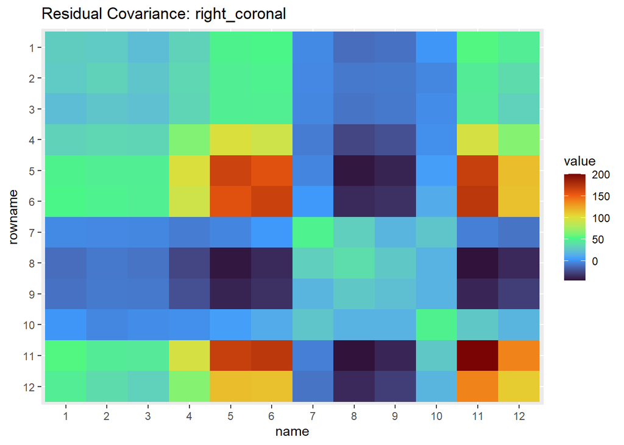

```r
Y <- vol_reg$model[[1]]

# Volumes
for(s in unique(cranio_reg$suture_type)){
  s_set <- which(cranio_reg$suture_type == s)

  cov_y <- cov(Y[s_set,]) %>%
    as.data.frame() %>%
    rownames_to_column() %>%
    pivot_longer(cols = -rowname) %>%
    mutate(across(c(rowname, name),
                  ~str_extract(., "[0-9]+") %>% as.numeric() %>% as.factor()))

  cov_resid <- cov(vol_reg$residuals[s_set,]) %>%
    as.data.frame() %>%
    rownames_to_column() %>%
    pivot_longer(cols = -rowname) %>%
    mutate(across(c(rowname, name),
                  ~str_extract(., "[0-9]+") %>% as.numeric() %>% as.factor()))

  cy <- ggplot(cov_y) +
    geom_tile(aes(x = name, y = rowname, fill = value)) +
    scale_fill_viridis_c(option = "turbo") +
    scale_y_discrete(limits = rev) +
    labs(title = paste("Volume Covariance:", s))

  cr <- ggplot(cov_resid) +
    geom_tile(aes(x = name, y = rowname, fill = value)) +
    scale_fill_viridis_c(option = "turbo") +
    scale_y_discrete(limits = rev) +
    labs(title = paste("Residual Covariance:", s))

  print(cy)
  print(cr)
}
```